# Attempting to Evaluate Effectivness of MLB Fastballs

## Re-Examining Association Between Count and Location, and xwOBA for Each Type of Fastball Using Heatmaps

There is yet another factor to consider. Earlier we looked at the average xwOBAs of pitches in each zone and compared them to the same plots, but for pitches that only had two strikes, to examine the implication of the count, or more specifically the number of strikes, on fastball effectiveness. Let's do the same thing here, but continuing with the theme of heatmaps, we'll use heatmaps instead of bar plots to better visualize the role location plays as well.

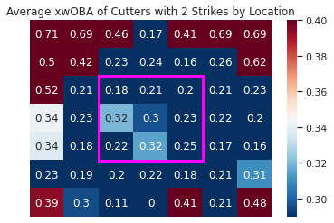

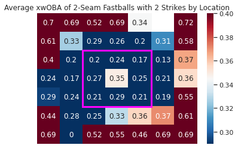

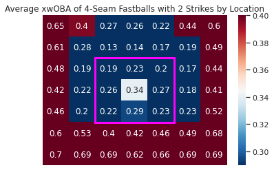

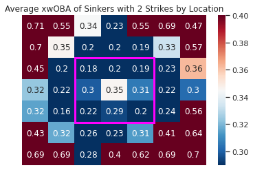

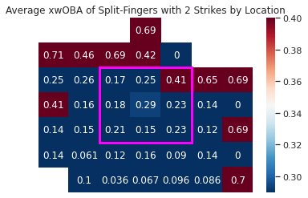

```python
#For each type of fastball
for pitch in fastballs['pitch_name'].unique():
    #Get subset of data that only includes pitches of that type AND with 2 strikes
    df = fastballs[(fastballs['pitch_name'] == pitch) & (fastballs['strikes'] == 2)]

    #Calculate average xwOBA for each location group
    grouped = df.groupby(['x_group', 'z_group']).mean()['xwOBA']

    #Reconfigure dataframe to correctly spatially orient the values
    grouped = grouped.reset_index().pivot(index='z_group', columns='x_group', values='xwOBA')
    grouped = grouped.reindex(index=grouped.index[::-1])

    #Plot the heatmap and draw strike zone
    ax = sns.heatmap(grouped, annot=True, cmap='RdBu_r', vmin=0.29, vmax=0.4)
    ax.add_patch(patches.Rectangle((2, 2), 3, 3, fill=False, edgecolor='magenta', lw=3))

    #Add title and turn off axis to make plot readable and display
    plt.title(f'Average xwOBA of {pitch}s with 2 Strikes by Location')
    ax.axis('off')
    plt.show()
```

Just like before, we can see that with 2 strikes pitches tend to become A LOT more effective. Cutters all of a sudden become effective more or less no matter where they are thrown except for way too high.

2-Seam Fastballs and Sinkers are still mostly just effective when they are near the strike zone, but are even more effective than they normally are. The only generally ineffective locations for them inside the strike zone are directly in the middle of the zone.

4-Seam Fastballs have a similar depiction as before, where they are not at all effective when throw below the strike zone, but with two strikes, they are ridiculously effective when thrown near the top of the zone or above it.

Lastly Splitters, similar to before are also not very effective when thrown above the strike zone, but when they are thrown below it they seem to be devastingly effective.

### Disclaimer

Now a lot of this is the product of the fact that we are only using pitches for which the at bat ended and there are two strikes, meaning that a lot of pitches were strikeouts. For example, if the count is 0-2 and the pitcher throws a splitter in the dirt below the strike zone and you already know that the at bat ended on that pitch, then you can likely confirm the pitch resulted in a strikeout. What our analysis doesn't show is the proportion of splitters that are thrown in the dirt that batters actually swing at, we just know that when they do, the outcome generally is not good for them.

All of this is to say that these plots should not be interpreted as "throwing splitters low in the zone is the most effective spot for them to be thrown". What it is saying is that batters do swing at these pitches, or more generally when at bats are decided on these pitches, splitters low in the zone tend to be very effective pitches with 2 strikes.

More analysis could be done to account for this, however that would require us to get more data regarding if a batter swung at a pitch or not, and we would not be able to use xwOBA for all of these because xwOBA can only be applied when an outcome occurs, that is when an at bat ends. This would complicate things considerably so in the interest of providing a much simpler tutorial I will not delve into this. However it is definitely something the interested reader could look into and is an important topic in assessing the general effectiveness of any pitch.

## Association Between Fastball Speed and Spin Rate, and xwOBA

So far we've examined the effects that count and pitch location, coupled with fastball type, have on xwOBA. But there are two other important components of pitches that we have't examined yet. These are the spin rate and velocity of the pitch.

Velocity, measured in miles per hour, is a self explanatory statistic and the logic is that the harder a ball is thrown we would expect that it is going to be more difficult to hit and thus have a lower xwOBA, if nothing else because the batter has less time to hit it.

Spin rate is the number of full rotations per minute a pitch makes when it is thrown. Pitches that have a higher spin rate (and thus spin more), tend to have more movement and "life" than other pitches, though there a some exceptions to this. See the [knuckle ball](https://www.youtube.com/watch?v=EgmQV9sodUA) for example. But in general increased spin rate leads to increased pitch movement, and the more something moves the more difficult it is to hit, so we expect higher spin rates to correlate with lower xwOBAs, similar to velocity.

To examine this we'll create another heatmap where each cell will show the average xwOBA for certain criteria. Except instead of the criteria being x and z coordinates, our criteria will be pitches in a certain velocity and spinrate range. So it is important to remember that this heatmap is not spatial like the previous ones were, they are mearly showing the average xwOBA for different ranges of velocities and spin rates of fastballs.

Just like we did with the location heat maps though, we will begin by creating our own custom interval ranges to group pitches into for velocity and spin rate. For velocity we will create ranges of 2 mph beginning from 70 mph all the way to 100 mph. We will also include a range for pitches that are 0-69.99 mph, and one for pitches that are 100+ mph.

For the spin rate we will create ranges of 200 rpm beginning from 1800 rpm all the way through 3000 rpm. We will include a range for fastballs 0-1799 rpm and those above 3000 rpm.

After that we will assign each pitch to a certain group based on its velocity and spin rate, and then we'll create a new dataframe that will store the average xwOBA of all pitches for each set of velocity and spinrate groups exactly like we did before with the location data. Then we just plot the heatmap with this data!

Let's do it now.

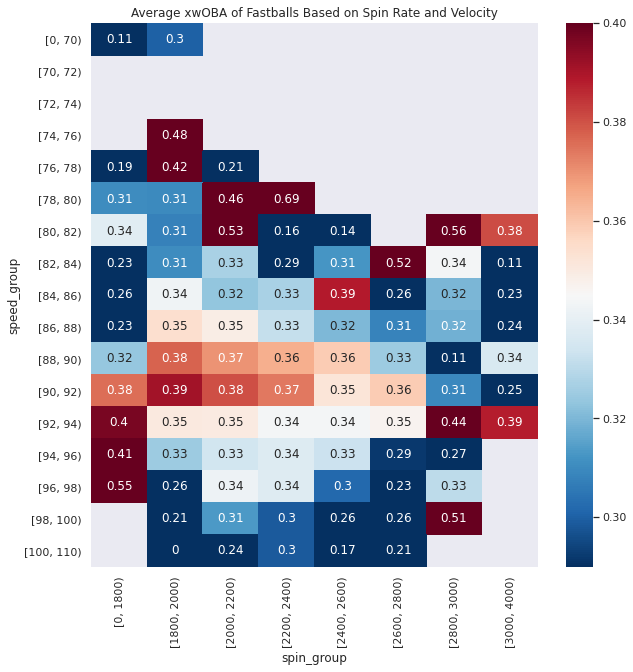

```python
#Creating custom intervals for spinrate and velocity
#Ranges of 200 rpm for spinrate and 2 mph for velocity
#Also include extreme ranges for fastballs below 70 mph or above 100 mph, and below 1800 rpm or above 3000 rpm
spin_bins = pd.IntervalIndex.from_tuples([(0, 1800)] + [(i, i+200) for i in range(1800, 3000, 200)] + [(3000, 4000)], closed='left')
speed_bins = pd.IntervalIndex.from_tuples([(0, 70)] + [(i, i+2) for i in range(70, 100, 2)] + [(100, 110)], closed='left')

#Assign each fastball to the appropriate spinrate and velocity group
fastballs['spin_group'] = pd.cut(fastballs['release_spin_rate'], bins=spin_bins)
fastballs['speed_group'] = pd.cut(fastballs['release_speed'], bins=speed_bins)

#Calculate average xwOBA of all fastballs in each set of groups and store in a dataframe
spin_speed = fastballs.groupby(['spin_group', 'speed_group']).mean()['xwOBA']

#Reorientate dataframe so that it can be used as input for the heatmap
spin_speed = spin_speed.reset_index().pivot(index='speed_group', columns='spin_group', values='xwOBA')

#Increase plot size to 10 x 10 inches
plt.figure(figsize=(10,10))

#Create heatmap, give title, and plot
sns.heatmap(spin_speed, annot=True, cmap='RdBu_r', vmin=0.29, vmax=0.4)
plt.title('Average xwOBA of Fastballs Based on Spin Rate and Velocity')
plt.show()
```

There a few things we can decipher from this heat map. The first is that there seems to be a bit of a rough spot for pitchers. Fastballs that are thrown around 90 mph with a spinrate around 200 rpm seem to get hit pretty hard, but any deviations from that either slower or faster for velocity, and any increase in spinrate seems to decrease xwOBA.

For fastballs thrown below 90 mph the average xwOBA seems to consistently hover around 0.32 which is league average. But the spin rate seems to have a similar effect to the one it has for pitches above 90 mph, in that as spin rate either increases or decreases the average xwOBA seems to decrease, and the closer the spin rate is to 2200-2400 rpm the higher the xwOBA seems to be.

This doesn't seem to align with what we originally thought would occur as we hypothesized that spin rate and velocity would both negatively correlate with xwOBA. Instead we see that there is a sort of "golden zone" for hitters: fastballs between 88 and 92 mph with a spin rate between 2000 and 2600 rpm. And generally as long as fastballs deviate from these ranges, no matter the direction, the average xwOBA of their fastballs decrease.

Remember though that this heatmap depicts the average xwOBA of **ALL** fastballs meeting criterion based on spin rate and velocity. However each type of fastball is not the same. 4-Seam Fastballs tend to have higher velocities than other fastballs. And Split-Fingers tend to have lower spin rates than other fastballs. So plotting all fastballs together might not be appropriate. Instead let's continue the theme of creating an individual plot for each type of fastball.

## Association Between Speed and Spin Rate, and xwOBA for Each Type of Fastball

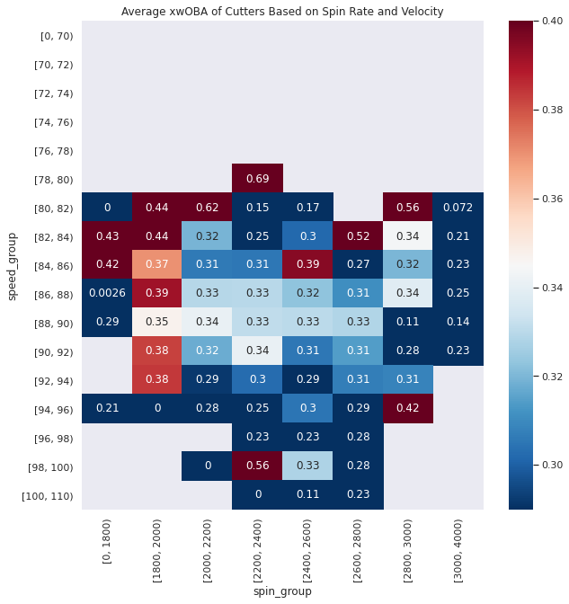

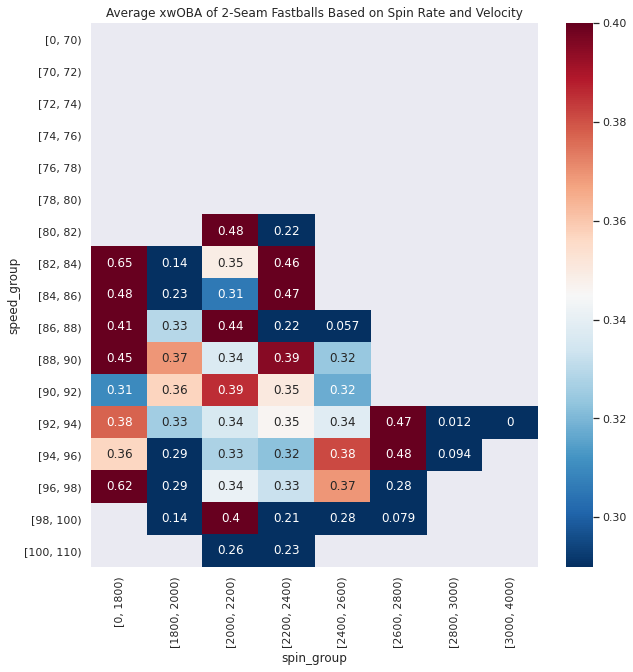

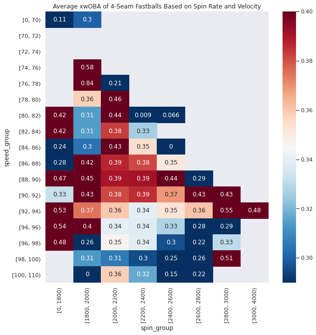

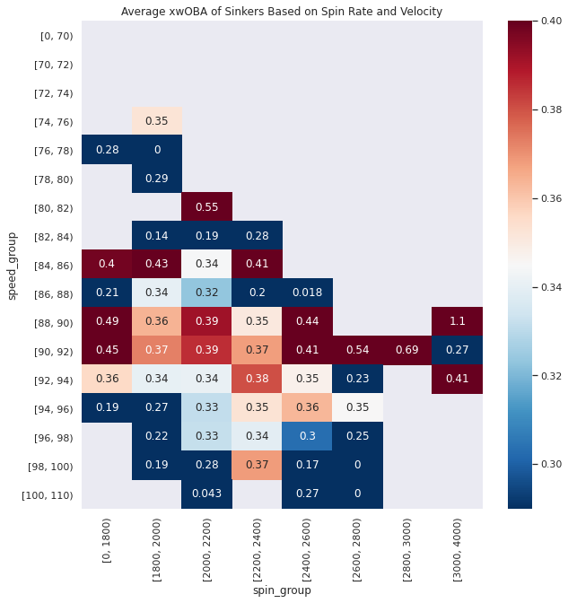

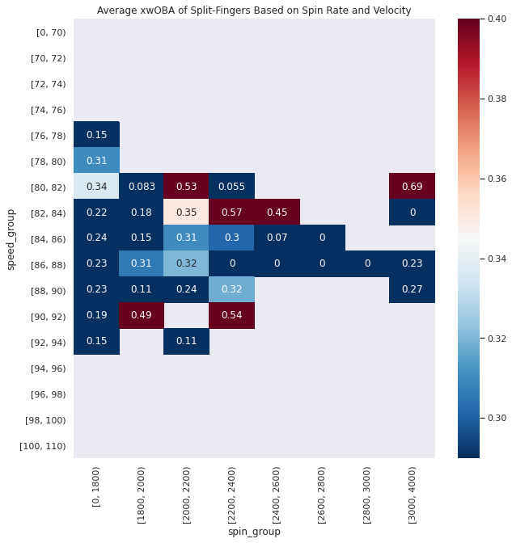

```python
#For each type of fastball
for pitch in fastballs['pitch_name'].unique():
    #Get subset of data that only includes fastballs of that type
    df = fastballs[fastballs['pitch_name'] == pitch]

    #Calculate average xwOBA of each fastball of that type in each group of velocity and spin rate
    spin_speed = df.groupby(['spin_group', 'speed_group']).mean()['xwOBA']

    #Reorientate dataframe to have it match spatial format heatmap requires
    spin_speed = spin_speed.reset_index().pivot(index='speed_group', columns='spin_group', values='xwOBA')

    #Customize size of figures to be 10 x 10 inches
    plt.figure(figsize=(10,10))

    #Create heatmap, add title, and show plot
    sns.heatmap(spin_speed, annot=True, cmap='RdBu_r', vmin=0.29, vmax=0.4)
    plt.title(f'Average xwOBA of {pitch}s Based on Spin Rate and Velocity')
    plt.show()
```

This is more useful. Through these individuals plots we can see that there are definite differences in trends regarding the xwOBA of fastballs based on velocity and spin rate depending on the type of fastball.

For 2-Seam Fastballs we can see that having a spin rate below 1800 regardless of the velocity tends to lead to poor results as the average xwOBA is pretty high for nearly all groups 2-Seam Fastballs that meet this criterion. Similar to cutters, 2-Seam Fastballs seem to perform best when they have a combination of high spin rate and high velocity. An interesting pattern emerges in 2-Seam Fastballs that seems to against this idea. 2-Seamers thrown with a spin rate between 1800 and 2000 rotations per minute seem to have very good results on average as long as they are either very fast (94+ mph) or very slow (below 86 mph). However this could just be random chance and variance, but is nonetheless interesting.

4-Seam Fastballs seem to have yet another similar story as cutters do. 4-Seam Fastballs thrown either too slow (below 90 mph) or with not enough spin rate (below 2200 rpm) seem to be fairly ineffective on average. But as 4-Seam Fastballs increase in both velocity and spin rate their average xwOBA tends to decrease and they become more effective. The threshold for velocity seems to be 98 mph based on this data for a 4-Seam to produce truly low xwOBAs on average, and interestingly at this velocity spin rate doesn't seem to play too much of a factor.

Split-Fingers seem to have pretty low average xwOBAs for nearly every grouping of spin rate and velocity but seem to be especially effective when thrown with a low spin rate (below 1800 rpm).

So looking at the heatmaps of velocity and spin rate for each pitch type definitely shed some light on the ways these factors impact effectiveness of each fastball, and do indicate they have an impact on the xwOBA and effectiveness of a fastball.

If there's one thing we can learn from these heatmaps its that each type of fastball is different from the other types of fastballs. This leads us to the following issue for which we will consequently present a solution. Each type of fastball has a different average velocity and spin rate, and has a different range of those quantities as well. A 95 mph 4-Seam Fastball may not be too fast, but a 95 mph Split-Finger is. This is because, as seen in the heatmaps, Split-Finger fastballs just aren't thrown nearly as hard as 95 mph, as there were zero Splitters that had velocities above 94 mph per the heatmap. So it isn't fair to compare different fastballs based on their raw speed and spin rates.

The solution to this is to standardize both of these variables for each fastball.

## Standardizing Velocity and Spin Rate for Each Type of Fastball

Standardizing data is a technique that can be used to evaluate different kinds of data by putting them on the same scale. We will standardize both spin rate and velocity for each fastball.

To standardize a value we simply subtract the mean of that value's group from the value itself, and then divide by the standard deviaiton of that group. For a concrete example, if the average velocity of 4-Seam Fastballs is 92 mph and the standard deviation of velocity of 4-Seam Fastballs is 2 mph, then a 4-Seam Fastball with a velocity of 95 mph would have a standardized velocity of (95 - 92) / 2 = 1.5.

These quantities are referred to as z-scores and they reprsent the number of deviations away a value is from the mean, where a positive value indicates it is above the mean, a negative value indicating it is below the mean, and a value of zero indicating it is equal to the mean.

Z-scores themselves are very interesting and standardization techniques using them are common in data science. If you are interested in why and how this works, or just want to learn more the [Wikipedia page](https://en.wikipedia.org/wiki/Standardization) on standardization is a good starting point.

```python
#computing mean and std deviation of each pitch type
means = fastballs.groupby('pitch_name').mean()[['release_spin_rate', 'release_speed']]
stds = fastballs.groupby('pitch_name').std()[['release_spin_rate', 'release_speed']]

#function that will take in a row and calculate it's z-score for velocity
def standard_velo(row):
    #get mean and standard deviation of velocity of fastball type
    mean = means.loc[row.loc['pitch_name'], 'release_speed']
    std = stds.loc[row.loc['pitch_name'], 'release_speed']

    #return standardized score
    return (row.loc['release_speed'] - mean) / std


#Creating new column of standardized velocities
fastballs['standard_velocity'] = fastballs.apply(standard_velo, axis=1)


#function that will take in a row and calculate it's z-score for spin rate
def standard_spin(row):
    #get mean and standard deviation of spin rate of fastball type
    mean = means.loc[row.loc['pitch_name'], 'release_spin_rate']
    std = stds.loc[row.loc['pitch_name'], 'release_spin_rate']

    #return standardized score
    return (row.loc['release_spin_rate'] - mean) / std


#Creating new column of standardized spin rates
fastballs['standard_spin_rate'] = fastballs.apply(standard_spin, axis=1)

fastballs.head()
```

|  | release_speed | events | zone | balls | strikes | plate_x | plate_z | release_spin_rate | xwOBA | pitch_name | count | x_group | z_group | spin_group | speed_group | standard_velocity | standard_spin_rate |
| --- | --- | --- | --- | --- | --- | --- | --- | --- | --- | --- | --- | --- | --- | --- | --- | --- | --- |
| 0 | 91.1 | strikeout | 14 | 2 | 2 | 0.08 | 1.02 | 2347.0 | 0.000 | Cutter | 2-2 | [-0.23666666666666664, 0.2366666666666667) | [0.8333333333333334, 1.5) | [2200, 2400) | [90, 92) | 0.811663 | -0.021496 |
| 1 | 98.3 | strikeout | 1 | 1 | 2 | -0.82 | 2.84 | 2268.0 | 0.000 | 2-Seam Fastball | 1-2 | [-1.1833333333333333, -0.71) | [2.833333333333333, 3.4999999999999996) | [2200, 2400) | [98, 100) | 2.037827 | 0.627089 |
| 2 | 97.0 | home_run | 4 | 3 | 2 | -0.68 | 2.39 | 2252.0 | 1.281 | 4-Seam Fastball | 3-2 | [-0.71, -0.23666666666666664) | [2.1666666666666665, 2.833333333333333) | [2200, 2400) | [96, 98) | 1.275922 | -0.197471 |
| 3 | 95.9 | field_out | 12 | 0 | 0 | 0.11 | 3.73 | 2251.0 | 0.006 | 4-Seam Fastball | 0-0 | [-0.23666666666666664, 0.2366666666666667) | [3.5, 4.166666666666667) | [2200, 2400) | [94, 96) | 0.860687 | -0.202939 |
| 4 | 94.5 | grounded_into_double_play | 6 | 2 | 1 | 0.40 | 2.29 | 2206.0 | 0.144 | Sinker | 2-1 | [0.2366666666666667, 0.71) | [2.1666666666666665, 2.833333333333333) | [2200, 2400) | [94, 96) | 0.715848 | 0.370369 |

Now that we've standardized each value we can recreate our general heat map of all fastballs using these standarized spin rates and velocities. The trends shown will be the same for the individual plots, but the similarity in scaling will allow for slightly easier analysis and comparisons.

Before doing so though we will need to recreate our intervals to group the standardized velocities and spin rates into. After that we'll have to follow the same process of before of creating a heatmap friendly spatially oriented dataframe.

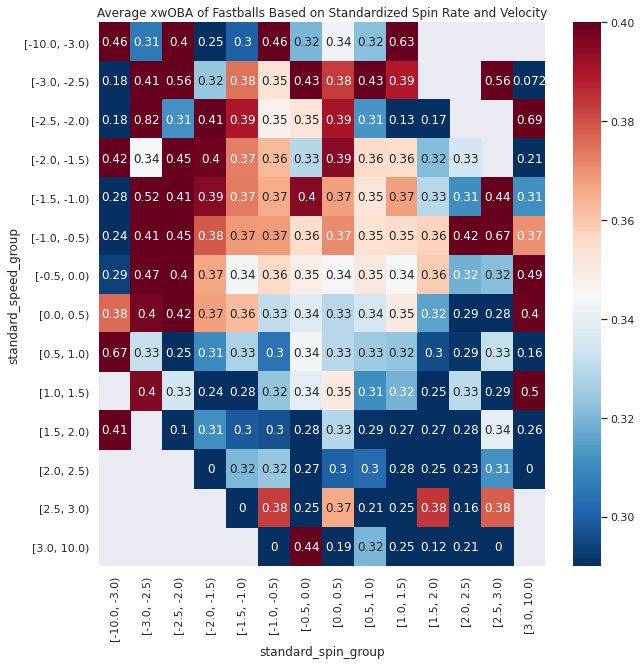

```python
#Creating custom intervals for spinrate and velocity
#Ranges of 200 rpm for spinrate and 2 mph for velocity
#Also include extreme ranges for fastballs below 70 mph or above 100 mph, and below 1800 rpm or above 3000 rpm
standard_bins = pd.IntervalIndex.from_tuples([(-10, -3)] + [(i / 2, (i + 1) / 2) for i in range(-6, 6)] + [(3, 10)], closed='left')

#Assign each fastball to the appropriate spinrate and velocity group
fastballs['standard_spin_group'] = pd.cut(fastballs['standard_spin_rate'], bins=standard_bins)
fastballs['standard_speed_group'] = pd.cut(fastballs['standard_velocity'], bins=standard_bins)

#Calculate average xwOBA of all fastballs in each set of groups and store in a dataframe
standard_spin_speed = fastballs.groupby(['standard_spin_group', 'standard_speed_group']).mean()['xwOBA']

#Reorientate dataframe so that it can be used as input for the heatmap
standard_spin_speed = standard_spin_speed.reset_index().pivot(index='standard_speed_group', columns='standard_spin_group', values='xwOBA')

#Increase plot size to 10 x 10 inches
plt.figure(figsize=(10,10))

#Create heatmap, give title, and plot
sns.heatmap(standard_spin_speed, annot=True, cmap='RdBu_r', vmin=0.29, vmax=0.4)
plt.title('Average xwOBA of Fastballs Based on Standardized Spin Rate and Velocity')
plt.show()
```

Now that we've standardized the spin rates and velocities of each fastball we can see a much clearer trend in fastball effectivness as measured by xwOBA. On average, fastballs thrown with above average velocities and above average spin rates tend to produce lower xwOBAs compared to fastballs with below average velocities and spin rates.

Let's look at these trends on an idividual level for each pitch type just like we did before to see if there are any other interesting trends that are now more visible due to the standadization of our data.

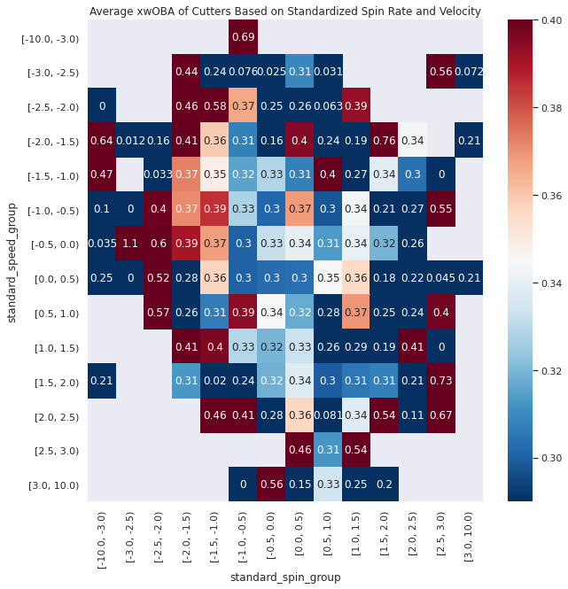

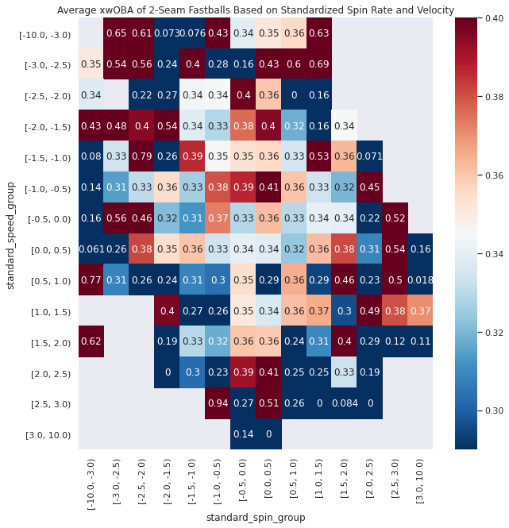

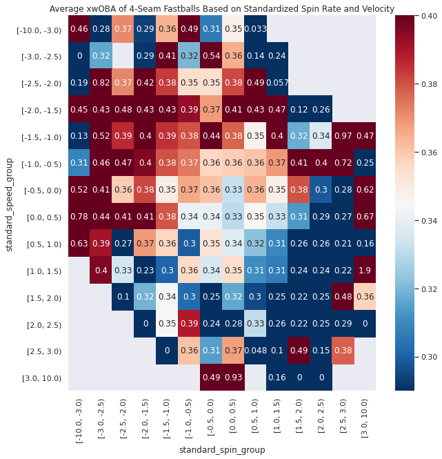

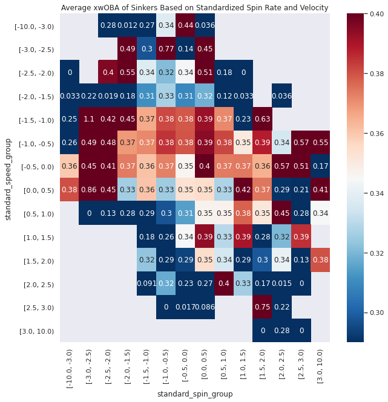

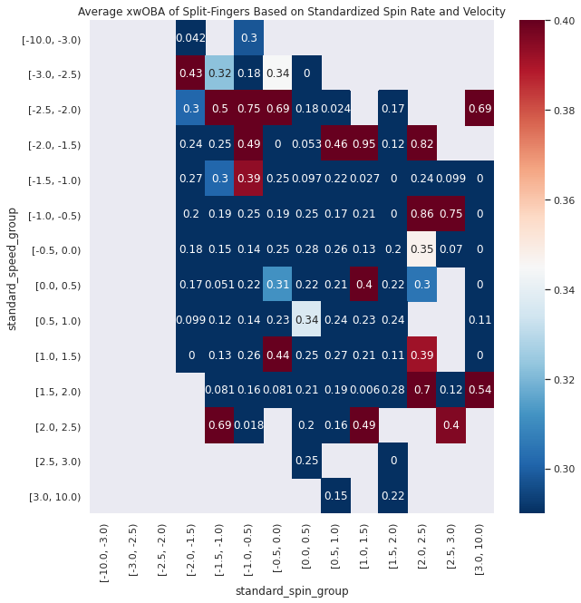

```python
#For each type of fastball
for pitch in fastballs['pitch_name'].unique():
    #Get subset of data that only includes fastballs of that type
    df = fastballs[fastballs['pitch_name'] == pitch]

    #Calculate average xwOBA of each fastball of that type in each group of velocity and spin rate
    standard_spin_speed = df.groupby(['standard_spin_group', 'standard_speed_group']).mean()['xwOBA']

    #Reorientate dataframe to have it match spatial format heatmap requires
    standard_spin_speed = standard_spin_speed.reset_index().pivot(index='standard_speed_group', columns='standard_spin_group', values='xwOBA')

    #Customize size of figures to be 10 x 10 inches
    plt.figure(figsize=(10,10))

    #Create heatmap, add title, and show plot
    sns.heatmap(standard_spin_speed, annot=True, cmap='RdBu_r', vmin=0.29, vmax=0.4)
    plt.title(f'Average xwOBA of {pitch}s Based on Standardized Spin Rate and Velocity')
    plt.show()
```

There don't seem to be any new trends that we couldn't already see from our previous heatmap analysis for each pitch type with non-standardized velocity and spin rates. However we can see that the trends seem a bit more exagerrated with these standardized scores instead, which gives us further confidence in these inferences.

## A Brief Discussion

We have done a very thorough exploratory analysis of our data. We can see pretty clearly that count, fastball location, fastball type, velocity, and spin rate all have an association or relationship with the xwOBA of the pitch. So as a result we can confidently say that these variables do seem to have a relationship with the effectiveness of a fastball.

What's more is that the heatmaps showed us that not only are they each associated with xwOBA, they also interact with each other. An example of this can be seen in the original heatmap showing xwOBA of all fastballs based on location. We could see that low fastballs had relatively high xwOBAs so there was an association between location and xwOBA. However when you incorporate pitch type and count, we can see that two strike splitters located low are actually better than located high. So when you combine multiple variables together the association may change entirely.

One thing is clear though, xwOBA and therefore fastball effectiveness has a pretty strong relationship with a variety of variables. Let's try and model this relationship in some way.

# Building a Machine Learning Model

Analyzing our data is great, but it's not super useful if we can't apply what we've learned to help us down the road. Luckily we can use our data to build a model to predict the effectiveness of a pitch!

## Sampling Methods and Population Representation

Before using **ANY** kind of model we need to ask ourselves if our data sample is representative of the larger population we are trying to model. You can't survey third graders about politics and use their responses to predict the outcome of the next presidential election, they're not representative of the larger voter poppulation you're trying to model and predict.

In our case our data consists of MLB pitches from the second half of the 2019 regular season. There is no reason to believe that the 2019 season and the fastballs thrown during it are drastically different from any of the current or near future fastballs that will be thrown, so it seems like our data sample is representative of the larger population.

There is a potential issue though and that is because we got our data using a clustering sample method. There are a few different methods for data sampling like Simple Random Sampling, Stratified Sampling, Clustered Sampling, and others. Clustered sampling is when you can view the population as a bunch of different groups of data and you randomly select certain groups from which to sample ALL of their data. In our case we could split MLB fastballs into groups by half years and we chose to sample all the data from a single group (or cluster). The risk is that if the cluster you get data from is not representative of the population at large, then you can't use it to make generalizations and predictions about the larger population. However in our case as we discussed, there is no reason to believe the second half of the 2019 MLB regular season is not reprsentative of the population at large.

An example where clustering would be a bad idea is in political polling. It has been shown that voting differs greatly by region, age, race, gender, and a myriad of other factors. If you were to do a clustering random sample and clustered by race then your data would not be useable for predictions. Imagine if you randomly selected the cluster of Hispanic voters then the only data you would have is from Hispanic voters which is obviously not representative of all voters.

Generally speaking stratified sampling is much better than clustered sampling because instead of randomly selecting one group and getting data from all its members, you instead get data from each group but instead only select a few members from each group. Though the best way to sample (in most cases) is using simple random sampling. Its the least prone to bias as it is inherently random and most likely to be representative of the population at large.

If you would like to read more about sampling methods [Scribbr](https://www.scribbr.com/methodology/sampling-methods/) has a great introduction to them. If you would like a more in depth explanation of each method and their pros and cons you can do so [here](https://www.healthknowledge.org.uk/public-health-textbook/research-methods/1a-epidemiology/methods-of-sampling-population)

## Picking a Model

So now that we've established that our data is representative of the population we can begin to pick the type of prediction model we would like to use.

Not all models are created equal and each have their own assumptions that go with them and therefore depending on the model certain coditions need to be met by the data.

One of the most basic and popular models is a linear regression model. This is when you use a mathematical equation to predict the values of some variables based on some other variables. In our case we would use information like the number of balls and strikes, along with pitch coodinate location and pitch type to predict xwOBA.

We could instead choose to use a polynomial regression model instead, which is the same as the linear model, but doesn't assume a linear relationship (instead it assumes a polynomial one). However there is another issue with this.

One assumption of the polynomial (and linear) regression model is that each explanatory variable is independent of each other, and this is not the case. We saw earlier that depending on the type of fastball thrown, a pitcher is more likely to throw it in certain areas of the strike zone. This means that fastball type and location are not independent of each other and as a result we can't apply a polynomial regression model using both of these variables together.

Another very popular and simple machine learning model is Decision and Regression Trees. The basic ways that tree based models work is they learn to ask a series of questions about the input data, eventually the answers to these questions lead them to predict the dependent variable. So these trees are in essence playing a game of 20 questions, where they learn the best questions to ask. One of the great things about these types of tree based models is that they require no assumptions of the data to be applied, other than the data being representative of the larger population it is being used to model.

Because these trees are so flexible we will be using them in this tutorial to predict xwOBA and pitch effectiveness. Another benefit of decision trees is that they are extremely easy to interpret and understand unlike many other machine learning models like neural networks for example.

If you would like to read more about different models and their respective assumptions and conditions you can do so [here](https://towardsdatascience.com/all-the-annoying-assumptions-31b55df246c3). For the more motivated readers, a very in depth guide of the most common machine learning models can be viewed [here](https://www.analyticsvidhya.com/blog/2017/09/common-machine-learning-algorithms/).

Ok so now that we've chosen the model we will be using let's do it!

## Splitting The Data

The first thing that should be done while building nearly any model is to split the data into two different sets. The training set and the test set. The only cases in which this might not be done (and even then it's rare) is when you're building a model without knowing the value of the variable you're trying to predict in the first place. However for us, because we want to predict xwOBA, and we know xwOBA, this is not the case and we should absolutely split our data into a training and test set.

The training set is used to build the model, while the test set is used to assess the model's accuracy. So in essence the training set is like a college professor, and the test set is the final exam for the model (and we get to decide if it fails or not).

The reason this is done is so that we can see how well the model performs when attempting to predict data values using values it hasn't already seen. Using the college analogy again, when we train the model we teach it by giving it the answers. But in reailty we want to use the model when we don't know the answer and hope that it can give it to us. So we need to withdraw some data (the test set) in order to see how well the model "answers questions" it hasn't seen yet. But because these "questions" are from the test set we know their answers and can use them to test how good of a model we have.

If you would like to learn more about splitting data into training and testing sets a great explanation and tutorial is provided in [this article](https://machinelearningmastery.com/train-test-split-for-evaluating-machine-learning-algorithms/) on Machine Learning Mastery.

Another very important reason to split data into training and testing sets is to help prevent the model from overfitting, more on this later.

Before splitting our data though there is one issue we have to resolve. To build our Regression Tree we will be using SciKit-Learn's Regression Tree module, which is not compatible with categorical data. So we can't use fastball type in the tree, which is obviously something we would want to do given the importance of it we've seen thus far. To remedy this we can transform our categorical fastball types into quantitative values using SciKit-Learn's Label Encoder.

Let's do that now.

```python
#Creating Label Encoder
le = LabelEncoder()

#Fitting the label encoder to get all fastball types
le.fit(fastballs['pitch_name'])

#Transforming pitch names to quantitative values
fastballs['pitch_transformed'] = le.transform(fastballs['pitch_name'])
```

SciKit-Learn also provides an inverse transform method so that we can get the fastball type based on its encoded value

```python
print('Here are all of the distinct fastball types that the Label Encoder encoded')
print(le.classes_)
print()
print('Here are all of the fastball types encoded via the Label Encoder')
print(le.transform(le.classes_))
print()
print('Here are the fastball types corresponding to each of the above encodings in order')
print(le.inverse_transform(le.transform(le.classes_)))
```

```
Here are all of the distinct fastball types that the Label Encoder encoded
['2-Seam Fastball' '4-Seam Fastball' 'Cutter' 'Sinker' 'Split-Finger']

Here are all of the fastball types encoded via the Label Encoder
[0 1 2 3 4]

Here are the fastball types corresponding to each of the above encodings in order
['2-Seam Fastball' '4-Seam Fastball' 'Cutter' 'Sinker' 'Split-Finger']
```

So we can see that 2-Seam Fastballs were encoded as 0, 4-Seam Fastballs as 1, etc.

We do have two other categorical variables, zone and count, however we can use their quantitative counterparts instead in pitch location (x and z coordinates), and balls and strikes.

So now that all of our data is represented quantitatively we can split our data into a training and testing set. Generally the majority of data is used to train the model while a small portion is left out for the testing. We'll use an 80-20 split, so 80 percent of our data will be put in the training set, and 20 percent in the test set.

```python
#explanatory variables
X_cols = ['standard_velocity', 'balls', 'strikes', 'plate_x', 'plate_z', 'standard_spin_rate', 'pitch_transformed']

#dependent variable
y_cols = ['xwOBA']

#Splitting data into training and testing set
X_train, X_test, y_train, y_test = train_test_split(fastballs[X_cols], fastballs[y_cols], test_size=0.2)
```

Now that we have split our data into a testing and training data set we can build a Regression Tree using SciKit-Learn and create our first model!

## Building a Regression Tree Model to Predict xwOBA

Before creating our regression tree model we need to talk about a few things regarding the cons associated with using regression trees. One of the biggest issues with Tree based models is that they tend to overfit.

In a nutshell overfitting in trees is when a model learns a really specific unrealistic set of rules based on the training data. As a result it doesn't really predict any values and instead just "remembers" that when you had this exact specific set of explanatory variable values, then the corresponding dependent variable was whatever it was. This is the same thing as memorizing multiplication tables but not knowing how to actually do multiplication. Sure you might know that 11 x 11 = 121, but only because someone told you that before, you don't know why it equals 121. So if someone asked you what 11 x 12 was you would have no idea what it is or how to determine it. This is a large issue because it means that you can't actual use the regression tree model to predict anything, which is the whole purpose of creating it in the first place.

Overfitting can also occur in linear regression and polynomial regression models, as well as almost any other machine learning model. If you want to learn more about it, how to detect it and remedy it, a great guide can be found [here](https://elitedatascience.com/overfitting-in-machine-learning).

Another issue with tree based models is that they don't tend to generalize well and aren't the best predictors for populations because the rules they can make regarding predictions are only based on the kind of data they've seen, and often times speficic rules are not generalizable.

However one way to test overfitting in a model, and to test how well a model can generalize is by splitting data into a training and testing set because it allows us to assess accuracy in a model and see how it performs when recieving data it hasn't seen before.

An indicator that a model is overfitting is if it scores really highly in the training set (very small error), but does much poorer in the testing set (has a much higher error).

Measures aside from splitting data into training and testing sets can also be taken to help prevent overfitting. The two main ones are to set a maximum depth for the tree, essentially limiting the number of rules it can make. This helps to prevent it from making a really specific set of rules to perfectly match the training data. Another method is to set the mininmum number of observations per leaf to a number greater than 1. This prevents the tree from making specific rules that result lead to only one observation.

SciKit-Learn has a great introduction to [good practices on tree models](https://scikit-learn.org/stable/modules/tree.html#tips-on-practical-use) if you want to learn more.

Another common issue with decision trees and many machine learning models is the dimensionality of the data. This is just a fancy way of saying you have a lot of explanatory variables, and not enough observations to accurately account for the effect each of these variables has on the dependent variables. Naturally, this occurrs when you either have a lot of explanatory variabels or too few observations or both. If this is the case you can try and reduce the dimension of your data by selecting only the most important explanatory variables to put into the model. There are also a variety of algorithms that can help remedy this issue as well. The above link to SciKit-Learn provides more information on this if you're interested.

Luckily though we have nearly 50,000 observations and only seven explanatory variables so dimensionality is not an issue in our case, but it is important to be aware of this.

Now that we've established what to be aware of and look out for in Tree based models, we can finally build one.

As a general practice, when building tree based models there are no magic values to set for the maximum depth of the tree or the minimum number of observations per leaf. Often times it takes trial and error to create trees and tweak the parameters until you either acheive an accurate model that doesn't seem to overfit, or you can't find one that meets these criteria and must pivot to another type of model.

With all that being said, let's build our regression tree model.

```python
#Creating the Decision Tree with custom parameters to help prevent overfitting
#Using the same random state to be able to tweak parameters and see direct consequences...
#...(eliminating random error in parameter tweaking)
xwOBA_predictor_tree = tree.DecisionTreeRegressor(max_depth=10, min_samples_leaf=2, random_state=11)

#Training the model
xwOBA_predictor_tree.fit(X_train, y_train)

#Testing the data and calculating our score
print(f"Score of Regression Tree xwOBA predictor on test data: {xwOBA_predictor_tree.score(X_test, y_test)}")
print(f"Score of Regression Tree xwOBA predictor on training data: {xwOBA_predictor_tree.score(X_train, y_train)}")
```

```
Score of Regression Tree xwOBA predictor on test data: 0.1215876762846756
Score of Regression Tree xwOBA predictor on training data: 0.18414851204914817
```

After creating the Regression Tree Model and training it on the training data we were able to test it on the test data. Above are the output scores of the model on each set of data.

A perfect score would be 1, the lower the score the worse the model does. For sake of reference a model that just predicts a constant value regardless of input (speficially the average xwOBA value) would have a score of 0. We can see clearly that our Regression Tree predictor of xwOBA performs very poorly on both the training data and test data, a sure sign of an unsucessful model. The max_depth and min_samples_leaf parameters could be tweaked, but would lead to even worse results.

Increasing the maximum depth of the tree did result in higher training scores, but led to even lower, and sometimes negative test scores, meaning that the predictor was even worse at predicting the xwOBA of a fastball than a model that would always spit out a constant xwOBA of 0.342 (the average of our sample).

Decreasing the minimum samples per leaf to 1 had next to no effect on these values interestingly enough, and increasing it didn't improve the test score and only harmed the training score.

So after much trial and error and tweaking of parameters it seems clear that unfortunately a tree based model is not appropriate at all or suitable for predicting xwOBA given our current data.

Unfortuantely because we cannot apply linear or polynomial regression to our data as discussed earlier, we do not have many other simple techniques that we can apply to build a model to predict xwOBA with our current data that are supervised learning models.

# Discussion of Results and Conclusions

Although it is unfortunate that we were not able to find a useful and simple model to predict the effectiveness of MLB fastballs, it is an accurate reflection of data science in the real world. Often times models fail and many quantities are extremely difficult to predict and require lots of sophisticated techniques and analysis. Not every relationship can be accurately modeled easily, and some not at all. Without a doubt in your data science career you will encounter these obstacles numerous times, so its important to be aware of them, and fitting that this tutorial illustrates this.

It also speaks to the difficulty that it can take to create accurate models in general, and also shows how difficult it can be to predict MLB success at a pitch by pitch level. If it were easy to predict success then it's likely that MLB teams would have figured this out already and we would be seeing video game numbers from every pitcher in baseball, instead of only seeing them from [Jacob deGrom](https://baseballsavant.mlb.com/savant-player/jacob-degrom-594798?stats=statcast-r-pitching-mlb).

However not all is lost as there were plenty of useful insights about the associations between factors such as location, velocity, spin rate, count, and pitch type, and xwOBA and fastball effectiveness. These insights might help us come up with new ideas for ways to model xwOBA and fastball effectiveness in the future, and still can provide worthwhile information to MLB pitchers about how to best utilize their fastballs.

Other areas that I would like to examine in the future include a similar analysis that includes all pitch types and not just fastballs. Another area of interest to look into might be how the sequencing of pitches can influence pitch effectiveness.

One potential flaw of the methods used in this tutorial was the clustered sampling mentioned earlier as it is always possible that the fastalls thrown in the second half of the 2019 MLB regular season is not representative of MLB fastballs overall, however this seems unlikely.

Hopefully though this tutorial showed the throughness required for a full, complete, and well done data science investigation into a topic, as well as the data science pipeline.

We began with the Data Collection which was simple enough. Then we moved on to the Data Curation and Filtering, where we removed unecessary rows and columns and dealt with missing values. After this we did plenty of Exploratory Data Analysis where we learned about a variety of patterns and associations between many different variables and pitch effectivness. We also standardized some of our data in order to get a clearer and more thorough understanding of some of these patterns. Lastly we applied a Machine Learning Model, specifically Regression Trees, in order to attempt to predict pitch effectivness as indicated by xwOBA, and while it was unsucessful, we still were able to learn a lot throughout the process.

# Resources and Further Reading

If you would like to learn more about data science, or Major League Baseball and the statistics used in this tutorial please see the following links.

### Plots and Graphs

- [Heatmaps](https://seaborn.pydata.org/generated/seaborn.heatmap.html)
- [Bar Plots](https://seaborn.pydata.org/generated/seaborn.barplot.html)
- [Kernel Density Estimator Plots](https://seaborn.pydata.org/generated/seaborn.kdeplot.html)

### Machine Learning

- [Common Algorithms](https://www.analyticsvidhya.com/blog/2017/09/common-machine-learning-algorithms/)
- [Loss Functions](https://heartbeat.fritz.ai/5-regression-loss-functions-all-machine-learners-should-know-4fb140e9d4b0#:~:text=The%20group%20of%20functions%20that,function%20is%20%E2%80%9Cgradient%20descent%E2%80%9D.)

### Major League Baseball

- [MLB](https://www.mlb.com/)
- [Fangraphs](https://www.fangraphs.com/)
- [Baseball Savant](https://baseballsavant.mlb.com/)
- [Statcast](https://www.mlb.com/glossary/statcast)

Good luck to you out there. And here's to hoping you don't run into a [Jacob deGrom fastball](https://www.youtube.com/watch?v=-4ZNTw1yw70) any time soon.